# Дискретные предикторы в линейных моделях

## Мы рассмотрим

- Линейные модели c непрерывными и дискретными предикторами

## Дискретные предикторы, или факторы

## Дискретные предикторы, или факторы

Это переменные, которые принимают несколько качественно различных значений, между которыми нет переходов.  
Разные значения одного и того же фактора называются **уровнями фактора**. Уровней может быть два и более.

Примеры:  
Если мы изучаем связь какой-либо величины (например, роста) с полом, то переменная `Sex` может принимать два значения: "F" и "M".  
F и M - это уровни фактора `Sex`.

Если мы изучаем связь экспрессии некоторого гена с введением какого-то вещества, то переменная `Treatment` может принимать три значения: "Control", "Drag_1", "Drag_2"  
"Control", "Drag_1", "Drag_2" - Это уровни фактора `Treatment`

## Геометрическая интерпретация моделей с непрерывным и дискретным предиктором

## В моделях с одним непрерывным предиктоом

Это одна линия, которая описывается уравнением \(y = b_0 + b_1x\)

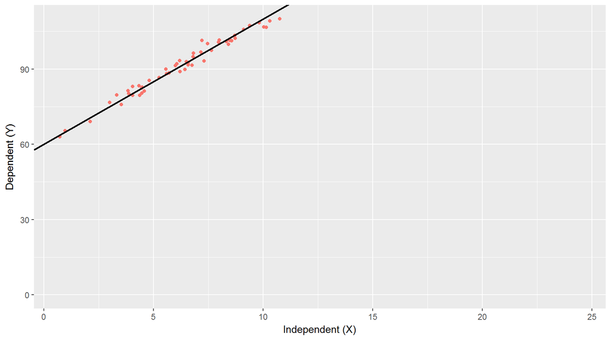

## В моделях с одним непрерывным предиктором и одним дискретным предиктором

В простейшем случае, когда есть только две градации дискретного фактора, - это две линии

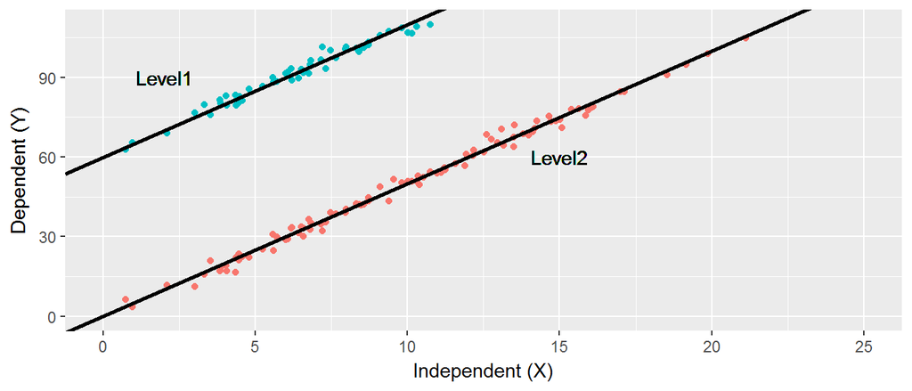

Если для каждой градации дискретного фактора характер связи между зависимой переменной \(y\) и непрерывным проректором \(x\) один и тот же (нет статистически значимого взаимодействия), то это две *параллельные* прямые.

Эти прямые отличаются только значениями `Intercept`

## Глистогонные и рост коз

Как связан прирост массы коз с начальным весом животного и интенсивностью профилактики паразитарных заболеваний?

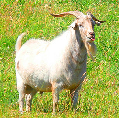

Goat by Jennifer C. [on Flickr](https://flic.kr/p/fjU4J9)

- `Treatment` - обработка от глистов (стандартная, интенсивная)
- `Weightgain` - привес, кг
- `Initial.wt` - начальный вес, кг

Пример из библиотеки данных http://www.statlab.uni-heidelberg.de/data/ancova/goats.story.html

## Читаем данные и знакомимся с ними

```r
library(readxl)
goat <- read_excel("data/goats.xlsx", sheet = 1)
head(goat)
```

```
## # A tibble: 6 x 3
##   Treatment Weightgain `Initial wt`
##       <chr>      <dbl>        <dbl>
## 1  standard          5           21
## 2  standard          3           24
## 3  standard          8           21
## 4  standard          7           22
## 5  standard          6           23
## 6  standard          4           26
```

```r
str(goat)
```

```
## Classes 'tbl_df', 'tbl' and 'data.frame':    40 obs. of  3 variables:
##  $ Treatment : chr  "standard" "standard" "standard" "standard" ...
##  $ Weightgain: num  5 3 8 7 6 4 8 6 7 5 ...
##  $ Initial wt: num  21 24 21 22 23 26 22 23 24 20 ...
```

## Читаем данные и знакомимся с ними

```r
colSums(is.na(goat))
```

```
##  Treatment Weightgain Initial wt
##          0          0          0
```

```r
# переименуем переменные для краткости
colnames(goat) <- c("Treatment", "Wt", "Init")
# объемы выборок
table(goat$Treatment)
```

```
##
## intensive  standard
##        20        20
```

```r
goat$Treatment <- factor(goat$Treatment)
```

## Есть ли выбросы?

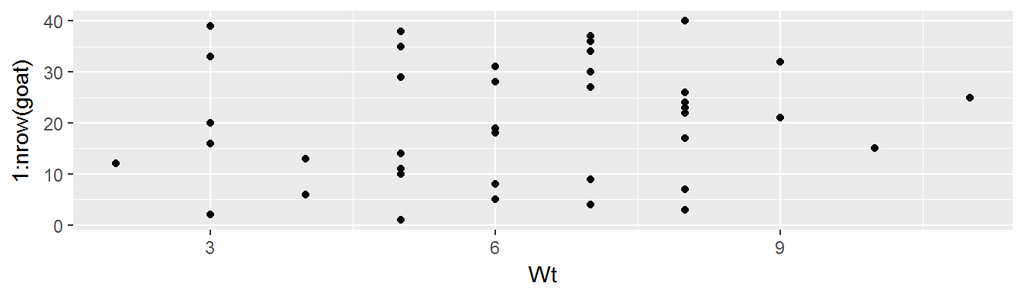

```r
library(ggplot2)
gg_dot <- ggplot(goat, aes(y = 1:nrow(goat))) + geom_point()
gg_dot + aes(x = Wt)
```

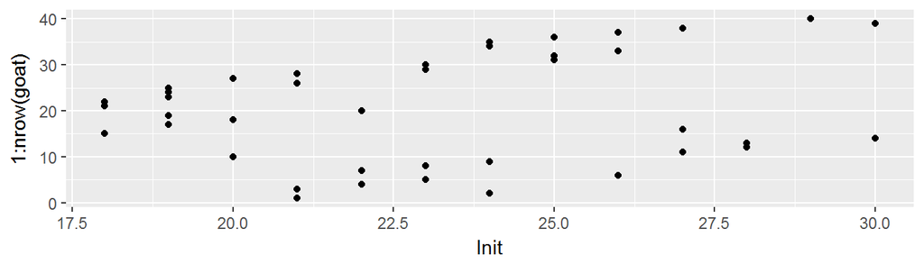

```r
gg_dot + aes(x = Init)
```

## Строим модель

```r
MG <- lm(Wt ~ Init + Treatment, data = goat)
```

В этой модели мы молчаливо считаем, что характер связи прироста коз с начальным весом будет одинаковым (нет взаимодействия предикторов). Но! Это надо специально проверять (об этом далее)

## Проверяем условия применимости

Пока не смотрим в `summary()`!

## Нет ли колинеарности между начальным весом и тритментом

```r
library(car)
vif(MG)
```

```
##      Init Treatment
##         1         1
```

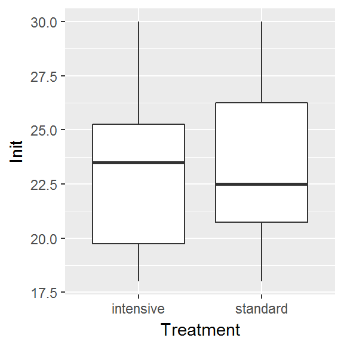

```r
ggplot(goat, aes(x = Treatment, y = Init)) + geom_boxplot()
```

Выраженной коллинеарности нет

## Проверяем условия применимости

Все хорошо

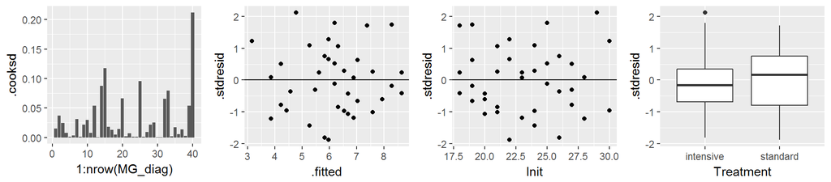

## Нормальнсть распределения остатков

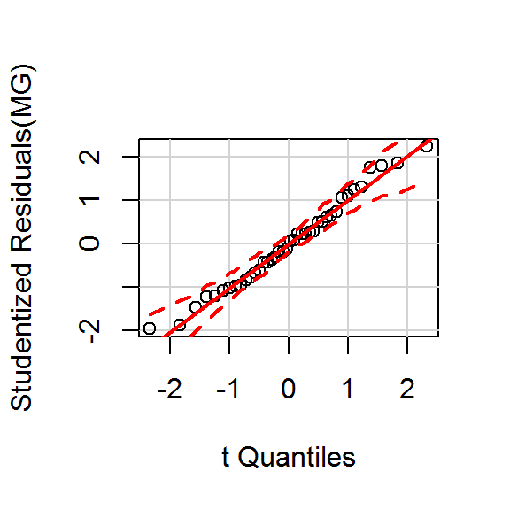

## График модели

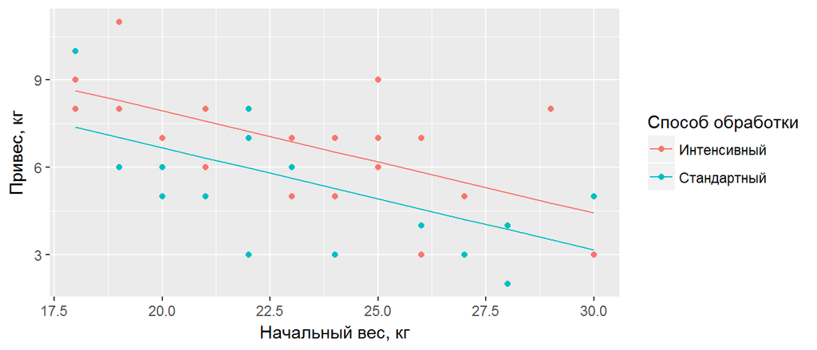

## Результаты

```r
summary(MG)
```

```
##
## Call:
## lm(formula = Wt ~ Init + Treatment, data = goat)
##
## Residuals:
##    Min     1Q Median     3Q    Max
## -2.972 -1.242 -0.034  0.988  3.223
##
## Coefficients:
##                   Estimate Std. Error t value      Pr(>|t|)
## (Intercept)        14.9666     1.7526    8.54 0.00000000028 ***
## Init               -0.3514     0.0742   -4.73 0.00003207789 ***
## Treatmentstandard  -1.2649     0.5117   -2.47         0.018 *
## ---
## Signif. codes:  0 '***' 0.001 '**' 0.01 '*' 0.05 '.' 0.1 ' ' 1
##
## Residual standard error: 1.62 on 37 degrees of freedom
## Multiple R-squared:  0.438,  Adjusted R-squared:  0.408
## F-statistic: 14.4 on 2 and 37 DF,  p-value: 0.0000233
```

В `summary()` появилась строка `Treatmentstandard`.

Почему не `Treatment`?

## Информация в `summary()` необходима для построения уравнения модели

У нас две линии

Первая: \[Wt = 14.97 - 0.3514 Init\]

Эта прямая описывает связь между и Init для той градации фактора `Treatment`, которая взята за **базовый уровень**. По умолчанию в качестве базового уровня берется первая по алфавиту градация дискретного фактора. В данном случае - это градация `intensive`

Вторая линия описывает связь между Wt и Init для второй градации фактора `Treatment`. уравнение этой прямой будет таким:

\[ Wt = 14.97 -0.3514 Init -1.2649 \\ Wt = 13.7 -0.3514 Init \]

## Смысл коэффициентов при дискретных предикторах

*Смысл 1.*  
Коэффициенты при дискретных предикторах показывают **на сколько единиц** смещается `Intercept` у данного (указанного в `summsry()`) уровня по отношению к базовому уровню

*Смысл 2.*  
На сколько единиц отличается среднее значение зависимой переменной для данного (указанного в `summsry()`) уровня от среднего значения зависимой переменной для базового уровня.

Уровень значимости в `summary()` говорит о статистической значимости этих отличий (при *попарном* сравнении; если уровней больше двух, то помните про проблемы множественности сравнений)

## Общее уравнение модели

Уравнение приобретает такой вид \[ Wt = 14.97 - 0.35Init - 1.26I_{standard} \] В этом уравнении появилась переменная \(I\) - это переменная-селектор (dummy variable, переменная-болванка)

\(I = 1\) если мы рассматриваем другой уровень дискретного предиктора. В данном случае уровень `Treatment` = "standard"

## Меняем базовый уровень

Это чисто формальная процедура от которой ничего не изменяется по сути, но это иногда необходимо для более удобной визуализации

```r
goat$Treatment <- relevel(goat$Treatment, ref = "standard")
levels(goat$Treatment)
```

```
## [1] "standard"  "intensive"
```

## Строим новую модель

```r
MG1 <- lm(Wt ~ Init + Treatment, data = goat)
```

## Результаты

```r
summary(MG1)
```

```
##
## Call:
## lm(formula = Wt ~ Init + Treatment, data = goat)
##
## Residuals:
##    Min     1Q Median     3Q    Max
## -2.972 -1.242 -0.034  0.988  3.223
##
## Coefficients:
##                    Estimate Std. Error t value     Pr(>|t|)
## (Intercept)         13.7017     1.7599    7.79 0.0000000026 ***
## Init                -0.3514     0.0742   -4.73 0.0000320779 ***
## Treatmentintensive   1.2649     0.5117    2.47        0.018 *
## ---
## Signif. codes:  0 '***' 0.001 '**' 0.01 '*' 0.05 '.' 0.1 ' ' 1
##
## Residual standard error: 1.62 on 37 degrees of freedom
## Multiple R-squared:  0.438,  Adjusted R-squared:  0.408
## F-statistic: 14.4 on 2 and 37 DF,  p-value: 0.0000233
```

Что изменилось?

## Уравнения

Общее уравнение модели

\[ Wt = 13.7017 -0.3514 Init + 1.2649 I_{intensive} \] Постройте уравнения для каждого из уровней фактора `Treatment`….

## Как охарактеризовать влияние двух предикторов в целом

```r
library(car)
Anova(MG, type = 3)
```

```
## Anova Table (Type III tests)
##
## Response: Wt
##             Sum Sq Df F value        Pr(>F)
## (Intercept)  190.9  1   72.93 0.00000000028 ***
## Init          58.6  1   22.40 0.00003207789 ***
## Treatment     16.0  1    6.11         0.018 *
## Residuals     96.9 37
## ---
## Signif. codes:  0 '***' 0.001 '**' 0.01 '*' 0.05 '.' 0.1 ' ' 1
```

## Вывод:

Привес коз при интенсивной обработке от глистов на 1.26 кг выше, чем при стандартном методе обработки (ANOVA, p =0.018). Привес коз демонстрирует отрицательную связь с начальным весом животного (ANOVA, p < 0.01).

## Применение моделей с дискретными предикторами

Когда это нужно?  
- Для демонстрации связи с непрерывными и дискретными предикторами одновременно в одной модели.  
- Если в фокусе нашего внимания влияние дискретного предиктора, но это влияние зависит от дополнительной переменной - *ковариаты* (такой анализ называется ANCOVA)

## ANCOVA

## Влияет ли стаж работы на предприятиях, вырабатывающих кадмий, на жизненнй объем легких?

Пример взят из книги: P. Armitage and G. Berry (1987), Statistical Methods in Medical Research, 2nd ed., Blackwell, p.286.

Данные представлены в пакете `ISwR`

Переменные:

`group` - Группа 1: Более 10 лет в отрасли; Группа 2 - менее 10 лет; Группа 3 - не подвергались воздействию.

`age` - возраст

`vital.capacity` - объем легких (л).

## Загружаем данные

```r
vit <- read.table("data/vitcap2.csv", header = TRUE, sep = ";")
```

## Немного преобразуем исходный датасет

```r
vit$Group [vit$group == 1] <- "Long exposed"
vit$Group [vit$group == 2] <- "Short exposed"
vit$Group [vit$group == 3] <- "Not exposed"
```

## Меняем порядок уровней

```r
vit$Group <- factor(vit$Group, levels = c("Not exposed", "Short exposed", "Long exposed"))

levels(vit$Group)
```

```
## [1] "Not exposed"   "Short exposed" "Long exposed"
```

## В фокусе исследования дискретная переменная

Нас интересует зависит ли объем легких (vital.capacity) от стажа работы (Group)

### Можно ли построить модель такого вида?

\[ vital.capacity = \huge {f} \normalsize (Group) \]

то есть модель должна быть основана только на дискретных предикторах.

Моделями с дискретными предикторами занимается классический **дисперсионный анализ**

## Модель с дискретным предиктором

```r
M1 <- lm(vital.capacity ~ Group, data = vit)
library(car)
Anova(M1, type = 3)
```

```
## Anova Table (Type III tests)
##
## Response: vital.capacity
##             Sum Sq Df F value Pr(>F)
## (Intercept)    876  1 1580.60 <2e-16 ***
## Group            3  2    2.48   0.09 .
## Residuals       45 81
## ---
## Signif. codes:  0 '***' 0.001 '**' 0.01 '*' 0.05 '.' 0.1 ' ' 1
```

## Геометрическая интерпретация модели с дискретным предиктором

Это будет график, отражающий средние значения зависимой переменной, вычисленные для каждой градации дискретного фактора

## Геометрическая интерпретация модели с дискретным предиктором

```r
MyData <- data.frame(Group = levels(vit$Group))

MyData$Group <- factor(MyData$Group, levels = c("Not exposed", "Short exposed", "Long exposed"))

MyData$Predicted <- predict(M1, newdata = MyData, se.fit = TRUE)$fit

MyData$SE <- predict(M1, newdata = MyData, se.fit = TRUE)$se.fit
```

## Геометрическая интерпретация модели с дискретным предиктором

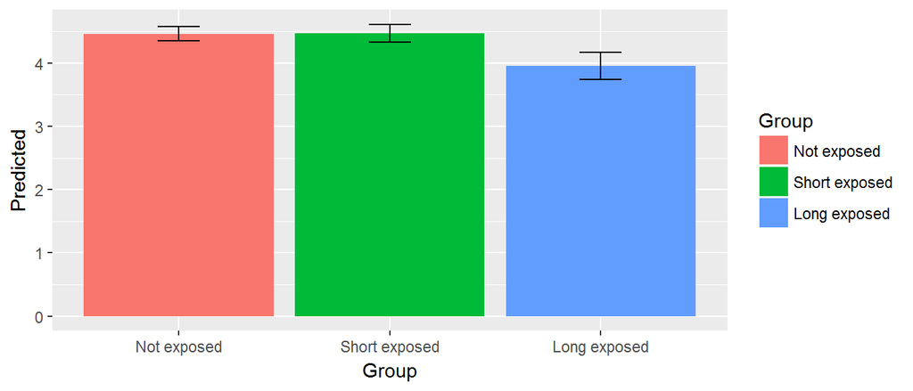

```r
library(ggplot2)
ggplot(MyData, aes(x = Group, y = Predicted)) +  geom_bar(stat = "identity", aes(fill = Group)) + geom_errorbar(aes(ymin = Predicted - SE, ymax = Predicted + SE), width = 0.2)
```

## Смотрим на результаты

```r
summary(M1)
```

```
##
## Call:
## lm(formula = vital.capacity ~ Group, data = vit)
##
## Residuals:
##     Min      1Q  Median      3Q     Max
## -1.7718 -0.4520  0.0981  0.5130  1.5708
##
## Coefficients:
##                    Estimate Std. Error t value Pr(>|t|)
## (Intercept)         4.46205    0.11223   39.76   <2e-16 ***
## GroupShort exposed  0.00974    0.17997    0.05    0.957
## GroupLong exposed  -0.51288    0.24245   -2.12    0.037 *
## ---
## Signif. codes:  0 '***' 0.001 '**' 0.01 '*' 0.05 '.' 0.1 ' ' 1
##
## Residual standard error: 0.744 on 81 degrees of freedom
## Multiple R-squared:  0.0577, Adjusted R-squared:  0.0344
## F-statistic: 2.48 on 2 and 81 DF,  p-value: 0.0902
```

Куда делась одна градация фактора?

- В качестве базового уровня предиктора `Group` взято значение "Not exposed"

## Запись модели с дискретными предикторами

Общая формула для модели

\[ vital.capacity = 4.46205 + 0.00974 \cdot I_{Short exposed} -0.51288 \cdot I_{Long exposed} \]

\(I\) - это переменные-селекторы (dummy variable)

## Запись модели с дискретными предикторами

Если мы хотим вычислить предсказание модели (значение объема легких) для любого индивида, имеющего `Group` = "Short exposed"

\[ vital.capacity = 4.46205 + 0.00974 \cdot 1 -0.51288 \cdot 0 = \\ = 4.46205 + 0.00974 = 4.47 \]

## Запись модели с дискретными предикторами

Если мы хотим вычислить предсказание модели (значение объема легких) для индивида, имеющего `Group` = "Long exposed"

\[ vital.capacity = 4.46205 + 0.00974 \cdot 0 -0.51288 \cdot 1 = \\ = 4.46205 -0.51288 = 3.95 \]

## Запись модели с дискретными предикторами

Если мы хотим вычислить предсказание модели (значение объема легких) для индивида, имеющего `Group` = "Not exposed"

\[ vital.capacity = 4.46205 + 0.00974 \cdot 0 -0.51288 \cdot 0 = \\ = 4.46205 \]

Это базовый уровень. Для него предсказанное значение равно `Intercept`

## Вернемся к результатам

Можно ли доверять полученным результатам?

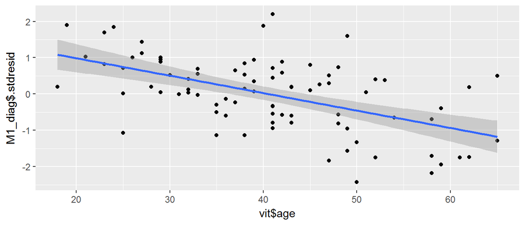

```r
M1_diag <- fortify(M1)
qplot(vit$age, M1_diag$.stdresid) + geom_smooth(method = "lm")
```

Очевидный паттерн в остатках!

Необходимо включать еще одну переменную - **`ковариату`**

## Analysis of covariance (ANCOVA)

### Меняем модель

```r
M3 <- lm(vital.capacity ~   Group + age , data = vit)
```

## Диагностика модели

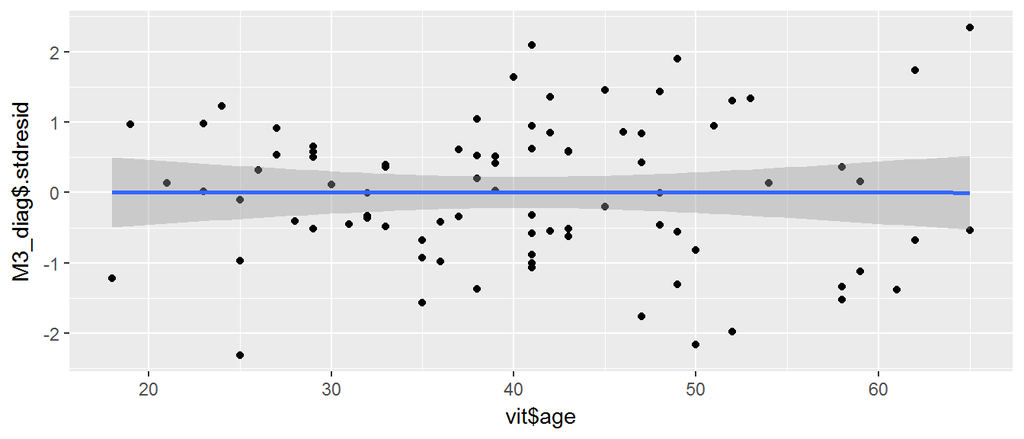

```r
M3_diag <- fortify(M3)
qplot(vit$age, M3_diag$.stdresid) + geom_smooth(method = "lm")
```

Паттерн исчез!

## Результаты

```r
summary(M3)
```

```
##
## Call:
## lm(formula = vital.capacity ~ Group + age, data = vit)
##
## Residuals:
##     Min      1Q  Median      3Q     Max
## -1.3805 -0.3805  0.0132  0.3791  1.3705
##
## Coefficients:
##                    Estimate Std. Error t value    Pr(>|t|)
## (Intercept)         6.04492    0.26802   22.55     < 2e-16 ***
## GroupShort exposed -0.07020    0.14867   -0.47        0.64
## GroupLong exposed  -0.11693    0.20924   -0.56        0.58
## age                -0.03978    0.00632   -6.29 0.000000016 ***
## ---
## Signif. codes:  0 '***' 0.001 '**' 0.01 '*' 0.05 '.' 0.1 ' ' 1
##
## Residual standard error: 0.613 on 80 degrees of freedom
## Multiple R-squared:  0.37,   Adjusted R-squared:  0.346
## F-statistic: 15.6 on 3 and 80 DF,  p-value: 0.0000000432
```

## Переменные-болванки (Dummy variables) на языке модельных матриц

Переменные-болванки присутствуют в модельной матрице в виде "меток"  
1 - если данное измерение (строчка) характреизуется данной градацей фактора.  
0 - если данное измерение (строчка) не характреизуется данной градацей фактора.

```r
X <- model.matrix(~ Group + age, data = vit)

X[c(1:3, 13:15, 41:43),]
```

```
##    (Intercept) GroupShort exposed GroupLong exposed age
## 1            1                  0                 1  39
## 2            1                  0                 1  40
## 3            1                  0                 1  41
## 13           1                  1                 0  29
## 14           1                  1                 0  29
## 15           1                  1                 0  33
## 41           1                  0                 0  27
## 42           1                  0                 0  25
## 43           1                  0                 0  24
```

## Задание

Используя матричную алгебру, найдите коэффициенты линейной модели для зависимой переменой `vital.capacity` на основе модельной матрицы `X`, включающей дискретный фактор `Group` и непрерывный предиктор `age`.

\[ \pmb{\beta} = [\textbf{X}'\textbf{X}]^{-1}[\textbf{X}'\textbf{y}] \]

## Решение

```r
Y <- vit$vital.capacity
betas <- solve(t(X) %*% X) %*% (t(X) %*% Y)
betas
```

```
##                       [,1]
## (Intercept)         6.0449
## GroupShort exposed -0.0702
## GroupLong exposed  -0.1169
## age                -0.0398
```

## Take home messages

- Нет разницы между моделями с дискретными и непрерывными предикторами
- При анализе влияния дискретного фактора часто необходимо учитывать влияние ковариаты.
- Пр тестировании гипотезы надо помнить о существовании двух типов тестирования: последовательное vs иерархическое.

## Что почитать

- Must read paper! , A.F. and Ieno, E.N., 2016. A protocol for conducting and presenting results of regression‐type analyses. Methods in Ecology and Evolution, 7(6), pp.636-645.
- Кабаков Р.И. R в действии. Анализ и визуализация данных на языке R. М.: ДМК Пресс, 2014
- Zuur, A., Ieno, E.N. and Smith, G.M., 2007. Analyzing ecological data. Springer Science & Business Media.
- Quinn G.P., Keough M.J. 2002. Experimental design and data analysis for biologists
- Logan M. 2010. Biostatistical Design and Analysis Using R. A Practical Guide